# Essential Sampling Methods Using R

Zuhal

2023-08-25

# Sampling Methods

## Simple Random Sampling

Random Sampling is one of the most popular and frequently used sampling methods. In a simple random sampling, every case in the population has an equal probability of getting selected in the sample.

Strengths

The selection of one element does not affect the selection of others. Each possible sample, of a given size, has an equal chance of being selected. Simple random samples tend to be good representations of the population. Requires little knowledge of the population.

Weaknesses

If there are small subgroups within the population, a SRS may not give an accurate representation of that subgroup. In fact, it may not include it at all! This is especially true if the sample size is small. If the population is large and widely dispersed, it can be costly (both in time and money) to collect the data.

```r
set.seed(10)
srs <- sample(1:nrow(df), 42, replace=T)
df.srs <- df %>% slice(srs)
head(df.srs)
```

```
## # A tibble: 6 × 29
##   Gender Student_Year  P1.1  P1.2  P1.3  P1.4  P1.5  P1.6  P1.7  P1.8  P1.9
##   <chr>         <dbl> <dbl> <dbl> <dbl> <dbl> <dbl> <dbl> <dbl> <dbl> <dbl>
## 1 Female         2018     3     3     3     3     3     3     3     3     4
## 2 Female         2018     4     5     3     5     5     3     3     3     4
## 3 Male           2020     4     4     5     5     4     4     4     4     4
## 4 Male           2017     3     3     4     4     4     2     3     3     4
## 5 Female         2018     5     5     5     5     5     5     5     5     5
## 6 Female         2020     5     5     4     5     5     5     5     4     5
## # ℹ 18 more variables: P1.10 <dbl>, P1.11 <dbl>, P1.12 <dbl>, P1.13 <dbl>,
## #   P2.1 <dbl>, P2.2 <dbl>, P2.3 <dbl>, P2.4 <dbl>, P2.5 <dbl>, P3.1 <dbl>,
## #   P3.2 <dbl>, P3.3 <dbl>, P3.4 <dbl>, P3.5 <dbl>, P3.6 <dbl>, P1_Total <dbl>,
## #   P2_Total <dbl>, P3_Total <dbl>
```

### SRS Without Replacement V2

```r
n <- 42
N <- nrow(df)
set.seed(314)
units <- sample(N, size = n, replace = FALSE)
df.srs2 <- df[units, ]
head(df.srs2)
```

```
## # A tibble: 6 × 29
##   Gender Student_Year  P1.1  P1.2  P1.3  P1.4  P1.5  P1.6  P1.7  P1.8  P1.9
##   <chr>         <dbl> <dbl> <dbl> <dbl> <dbl> <dbl> <dbl> <dbl> <dbl> <dbl>
## 1 Female         2019     2     2     4     2     2     3     1     1     3
## 2 Female         2018     4     2     2     3     3     2     2     1     4
## 3 Female         2020     4     3     4     4     4     4     3     3     5
## 4 Male           2019     3     3     3     5     2     3     3     2     2
## 5 Male           2019     3     3     3     3     3     3     3     3     3
## 6 Male           2017     5     5     4     5     4     4     4     4     4
## # ℹ 18 more variables: P1.10 <dbl>, P1.11 <dbl>, P1.12 <dbl>, P1.13 <dbl>,
## #   P2.1 <dbl>, P2.2 <dbl>, P2.3 <dbl>, P2.4 <dbl>, P2.5 <dbl>, P3.1 <dbl>,
## #   P3.2 <dbl>, P3.3 <dbl>, P3.4 <dbl>, P3.5 <dbl>, P3.6 <dbl>, P1_Total <dbl>,
## #   P2_Total <dbl>, P3_Total <dbl>
```

### SRS With Replacement

```r
set.seed(10)
srs2 <- sample(1:nrow(df), 42, replace=T)
```

### Cumulative Distribution Function

```r
# This is the range of our x scale in cdf graph below
max(df.srs2$P2_Total)
```

```
## [1] 25
```

```r
min(df.srs2$P2_Total)
```

```
## [1] 10
```

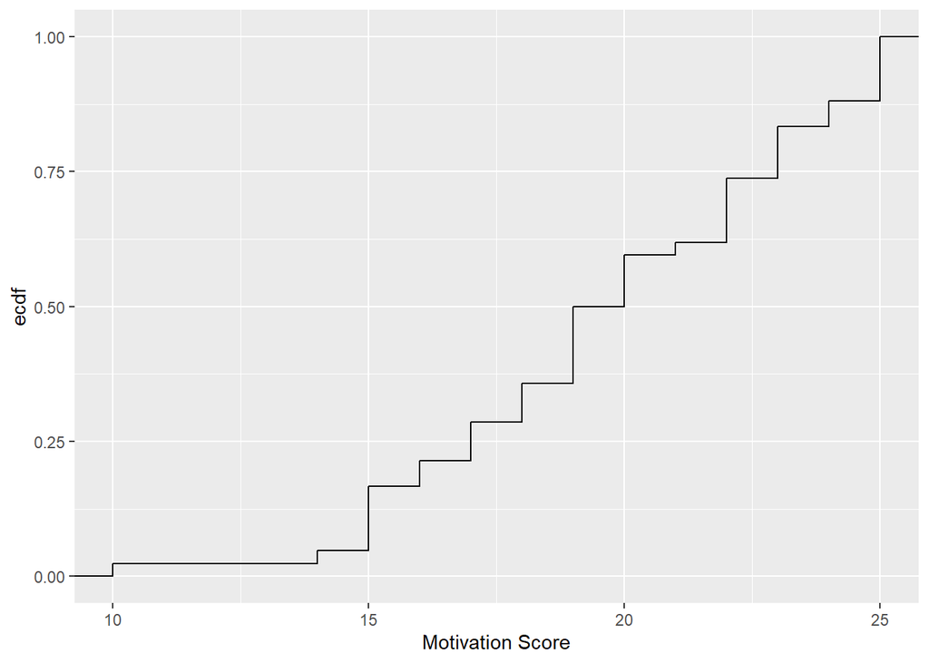

```r
ggplot(df.srs2, mapping = aes(P2_Total)) +
  stat_ecdf(geom = "step") +
  scale_x_continuous(name = "Motivation Score") #+
```

```r
  #scale_y_continuous(name = "?")
```

### Quantiles

The estimated CDF shows jumps of size 1/n ,so that the estimated population proportion can be larger than the desired proportion. The estimated population proportions therefore are often interpolated, for instance linearly. Function quantile of the stats package can be used to estimate a quantile. With argument type = 4 linear interpolation is used to estimate the quantiles.

Function quantile actually computes sample quantiles, i.e., it assumes that the population units are selected with equal inclusion probabilities (as in simple random sampling), so that the estimators of the population proportions obtained are unbiased. With unequal inclusion probabilities these probabilities must be accounted for in estimating the population proportions

```r
quantile(df.srs2$P2_Total, probs = c(0.25, 0.5, 0.75), type = 4) %>%  round(1)
```

```
##  25%  50%  75%
## 17.0 19.0 22.5
```

Package QuantileNPCI (N. Hutson, Hutson, and Yan 2019) can be used to compute a non-parametric confidence interval estimate of a quantile, using fractional order statistics (A. D. Hutson 1999). Parameter q specifies the proportion.

```r
quantCI(df.srs2$P2_Total, q = 0.5, alpha = 0.05, method = "exact")
```

```
## $u1
## [1] 0.3531218
##
## $u2
## [1] 0.6468782
##
## $lower.ci
## 35.312182278177th percentile
##                      18.18424
##
## $qx
## 50th percentile
##             19.5
##
## $upper.ci
## 64.687817721823th percentile
##                            22
```

### Sampling variance of estimator of population parameters

Although there is no advantage in using package survey (Lumley 2021) to compute the π estimator and its standard error for this simple sampling design, we will do it for a better understanding of future explanation about cluster sampling.

First, the sampling design that is used to select the sampling units is specified with function svydesign. The first argument specifies the sampling units. In this case, Formula or data frame specifying cluster ids from largest level to smallest level, ~0 or ~1 is a formula for no clusters. Argument probs specifies the inclusion probabilities of the sampling units. Alternatively, we may specify the weights with argument weights, which are in this case equal to the inverse of the inclusion probabilities. Variable pi is a column in tibble df.srs2, which is indicated with the tilde in probs = ~ pi.

The population mean is then estimated with function svymean. The first argument is a formula specifying the study variable. Argument design specifies the sampling design.

```r
df.srs2$pi <- n / N
design_srs <- svydesign(id = ~ 1, probs = ~ pi, data = df.srs2)
svymean(~ P2_Total, design = design_srs)
```

```
##            mean     SE
## P2_Total 19.667 0.5638
```

For simple random sampling of finite populations without replacement, argument fpc is used to correct the standard error.

```r
df.srs2$N <- N
design_srs_fpc <- svydesign(id = ~ 1, probs = ~ pi,
                            fpc = ~ N, data = df.srs2)
svymean(~ P2_Total, design_srs_fpc)
```

```
##            mean     SE
## P2_Total 19.667 0.3987
```

Population totals can be estimated with function svytotal, quantiles with function svyquantile, and ratios of population totals with svyratio, to mention a few functions that will be used in following chapters.

```r
svyquantile(~ P2_Total, design_srs, quantile = c(0.5, 0.9))
```

```
## $P2_Total
##     quantile ci.2.5 ci.97.5        se
## 0.5       19     18      22 0.9903241
## 0.9       25     25      25 0.0000000
##
## attr(,"hasci")
## [1] TRUE
## attr(,"class")
## [1] "newsvyquantile"
```

The cumulative density function gives you the probability of a random variable being on or below a certain value. The quantile function is the opposite of that. i.e. you give it a probability and it tells you the random variable value. So the median is the value of the quantile at the probability value of 0.5. A quartile is the value of the quantile at the probabilities 0.25, 0.5 and 0.75. So, in general, you can use the quantile. The quartile is a special case.

To understand Quantiles you need to understand the term “Percentile” first which will make your equation far more relevant. Percentile Basically says where do you lie in a Sorted List.

For Example: x={x1,x2,x3……………….x50,x51,………………….x100} n = 100

So the value at the 10th index in the sorted list gives the 10th percentile. What this percentile tells us is basically 10% of the values are less than this point and 90% of values are more than this point. The 50th percentile in this case will be known as the Median. If I tell you the (.01, 0.05, 0.10, 0.25, 0.5, 0.75, 0.90, 0.95 and 0.99) quantile, you will have a pretty good picture for most policy purposes.

### Confidence Interval Estimate

A second way of expressing our uncertainty about the estimated total, mean, or proportion is to present not merely a single number, but an interval. The wider the interval, the more uncertain we are about the estimate, and vice versa, the narrower the interval, the more confident we are.

we can use method confint of package survey to compute the confidence interval.

```r
confint(svymean(~ P2_Total, design_srs), df = degf(design_srs),
                level = 0.95)
```

```
##             2.5 %   97.5 %
## P2_Total 18.52809 20.80524
```

Perspective from books: The interpretation of a confidence interval is not straightforward. A common misinterpretation is that if the 0.90 confidence interval estimate of the population mean equals [a,b], then the probability that the population mean is in this interval equals 0.90. In classical sampling theory, this cannot be a correct interpretation, because the population mean is not a random variable, and consequently the probability that the population mean is in an interval does not exist. However, the estimated bounds of the confidence interval are random variables, because the estimated population mean and also the estimated sampling variance vary among samples drawn with a probability sampling design. Therefore, it does make sense to attach a probability to this interval.

## Systematic Sampling

Systematic sampling is used in situations where the population data is an ordered list or is arranged in time. For eg, to analyze the average sales of a shop on all Sundays, systematic sampling can be used by choosing the average sales data of all the 7th day(Sunday) of the week to be included in the sample.

```r
df.ordered <- arrange(df, Student_Year)
```

```r
getsys = function(N,n){
  k = ceiling(N/n)
  r = sample(1:k, 1)
  seq(r, r + k*(n-1), k)
}
```

```r
set.seed(123)
df.sys <- df.ordered[getsys(nrow(df.ordered), 42), ]
head(df.sys)
```

```
## # A tibble: 6 × 29
##   Gender Student_Year  P1.1  P1.2  P1.3  P1.4  P1.5  P1.6  P1.7  P1.8  P1.9
##   <chr>         <dbl> <dbl> <dbl> <dbl> <dbl> <dbl> <dbl> <dbl> <dbl> <dbl>
## 1 Male           2017     5     5     4     5     4     4     4     4     4
## 2 Male           2017     3     2     3     4     2     3     2     3     3
## 3 Male           2017     2     2     3     3     2     2     2     2     4
## 4 Female         2017     3     2     4     4     4     3     3     2     4
## 5 Female         2017     3     2     1     5     2     1     1     1     3
## 6 Female         2017     5     2     3     5     3     3     2     3     4
## # ℹ 18 more variables: P1.10 <dbl>, P1.11 <dbl>, P1.12 <dbl>, P1.13 <dbl>,
## #   P2.1 <dbl>, P2.2 <dbl>, P2.3 <dbl>, P2.4 <dbl>, P2.5 <dbl>, P3.1 <dbl>,
## #   P3.2 <dbl>, P3.3 <dbl>, P3.4 <dbl>, P3.5 <dbl>, P3.6 <dbl>, P1_Total <dbl>,
## #   P2_Total <dbl>, P3_Total <dbl>
```

## Stratified Sampling

In stratified sampling, the population is divided into smaller subgroups based on some common factors that best describe the entire population like age, sex, income, etc. The groups thus formed are known as stratum/strata.

For example, to analyze the amount of time spent by male and female users in sending messages per day, the strata could be taken as male and female users and random sampling can be used to select items within the male and female strata.

A probability sample is selected by some sampling design. If these probability samples are selected by simple random sampling, as previously described, the design is stratified simple random sampling, that we will compute here. If sampling units are selected by cluster random sampling, then the design is stratified cluster random sampling.

Note: Stratified sampling gives precise estimates compared to random sampling but the biggest disadvantage is that it requires knowledge of the appropriate characteristics of the population(the details of which are not always available), and it can be difficult to decide which characteristics to stratify by.

```r
# Using dplyr
set.seed(7)
df.stratified <- df %>%
  group_by(Student_Year) %>%
  sample_n(10)
```

```r
table(df.stratified$P1.12) # P1.12 = They who have same goal with org
```

```
##
##  1  2  3  4  5
##  1  3 14 19  3
```

### Manual Computing for Proportional Stratified Sampling

Formula: (sample size/population size) × stratum size

```r
count(filter(df.ordered, Student_Year == 2017))
```

```
## # A tibble: 1 × 1
##       n
##   <int>
## 1    13
```

```r
count(filter(df.ordered, Student_Year == 2018))
```

```
## # A tibble: 1 × 1
##       n
##   <int>
## 1    26
```

```r
count(filter(df.ordered, Student_Year == 2019))
```

```
## # A tibble: 1 × 1
##       n
##   <int>
## 1    25
```

```r
count(filter(df.ordered, Student_Year == 2020))
```

```
## # A tibble: 1 × 1
##       n
##   <int>
## 1    20
```

```r
#Formula, where we want 40 proportional sample from data set
(40/84)*13 #2017
```

```
## [1] 6.190476
```

```r
(40/84)*26 #2018
```

```
## [1] 12.38095
```

```r
(40/84)*25 #2019
```

```
## [1] 11.90476
```

```r
(40/84)*20 #2020
```

```
## [1] 9.52381
```

```r
# Ideal Proportion
6.190476 + 12.38095 + 11.90476 + 9.52381
```

```
## [1] 40
```

```r
# Thus,
# 6 for 2017, 12 for 2018, 12 for 2019, 10 for 2020
```

```r
df2017 <- filter(df, Student_Year == 2017)
srs2017 <- sample(1:nrow(df2017), 6)
df2017 <- df2017 %>% slice(srs2017)

df2018 <- filter(df, Student_Year == 2018)
srs2018 <- sample(1:nrow(df2018), 12)
df2018 <- df2018 %>% slice(srs2018)

df2019 <- filter(df, Student_Year == 2019)
srs2019 <- sample(1:nrow(df2019), 12)
df2019 <- df2019 %>% slice(srs2019)

df2020 <- filter(df, Student_Year == 2020)
srs2020 <- sample(1:nrow(df2020), 10)
df2020 <- df2020 %>% slice(srs2020)

PSS <- rbind(df2017, df2018, df2019, df2020)
head(PSS)
```

```
## # A tibble: 6 × 29
##   Gender Student_Year  P1.1  P1.2  P1.3  P1.4  P1.5  P1.6  P1.7  P1.8  P1.9
##   <chr>         <dbl> <dbl> <dbl> <dbl> <dbl> <dbl> <dbl> <dbl> <dbl> <dbl>
## 1 Male           2017     5     5     4     5     4     4     5     4     5
## 2 Male           2017     3     3     4     4     4     2     3     3     4
## 3 Female         2017     3     2     4     5     5     1     2     3     4
## 4 Female         2017     5     4     3     5     4     4     5     4     5
## 5 Female         2017     5     2     3     5     3     3     2     3     4
## 6 Male           2017     3     2     3     4     2     3     2     3     3
## # ℹ 18 more variables: P1.10 <dbl>, P1.11 <dbl>, P1.12 <dbl>, P1.13 <dbl>,
## #   P2.1 <dbl>, P2.2 <dbl>, P2.3 <dbl>, P2.4 <dbl>, P2.5 <dbl>, P3.1 <dbl>,
## #   P3.2 <dbl>, P3.3 <dbl>, P3.4 <dbl>, P3.5 <dbl>, P3.6 <dbl>, P1_Total <dbl>,
## #   P2_Total <dbl>, P3_Total <dbl>
```

### Stratified Weighted Sampling

The larger a stratum, the more units are selected from this stratum. The sizes of the strata, i.e., the total number of grid cells, are computed with function tapply.

Note: Make sure your stratum has ordered and also in a char data type

```r
df.ordered$Student_Year <- as.character(df.ordered$Student_Year)
N_h <- tapply(df.ordered$Student_Year, INDEX = df.ordered$Student_Year, FUN = length)
w_h <- N_h / sum(N_h)
n <- 40
print(n_h <- round(n * w_h))
```

```
## 2017 2018 2019 2020
##    6   12   12   10
```

The results have same values as previous method. If the results is more than desired sample (40) you can reduce the largest stratum sample size as needed.

```r
#n_h[3] <- n_h[1] - 1 #reduce 1 sample from 2019 strata
```

The stratified simple random sample is selected with function strata of package sampling (Tillé and Matei 2021). Argument size specifies the stratum sample sizes.

```r
ord <- unique(df.ordered$Student_Year)
set.seed(314)
units <- sampling::strata(df.ordered, stratanames = "Student_Year",
                          size = n_h[ord], method = "srswor")
df.stratified.v2 <- getdata(df.ordered, units)
```

### Estimation of Population Parameters

With simple random sampling within strata, the estimator of the population mean for simple random sampling (Equation (3.2)) is applied at the level of the strata. The estimated stratum means are then averaged, using the relative sizes or areas of the strata as weights For stratified simple random sampling with replacement of finite populations and stratified simple random sampling of infinite populations the fpcs 1−(nh/Nh) can be dropped.

```r
# m = mean
# z = target variable = P2_Total = Motivation Variable
# h = stratum
# nh = the sample size of stratum h
# Nh = the size of stratum h (total)
# The inclusion probabilities differ among the strata and equal πk = nh/Nh for all k in stratum h
# S2 = capital S squared (variance of a sample)

# The estimated mean of each stratum h
mz_h <- tapply(df.stratified.v2$P2_Total,
               INDEX = df.stratified.v2$Student_Year,
               FUN = mean)
mz_h
```

```
##     2017     2018     2019     2020
## 19.83333 20.25000 18.50000 20.30000
```

```r
# The estimator of the population mean for simple random sampling is applied at the level of the strata. The estimated stratum means are then averaged, using the relative sizes or areas of the strata as weights
mz <- sum(w_h * mz_h)
mz
```

```
## [1] 19.67659
```

```r
# The estimated sample variance of z within each stratum h
S2z_h <- tapply(df.stratified.v2$P2_Total,
                INDEX = df.stratified.v2$Student_Year,
                FUN = var)
S2z_h
```

```
##      2017      2018      2019      2020
## 25.366667 12.204545 18.818182  7.122222
```

```r
# The estimated sampling variance of mean z in stratum h
v_mz_h <- S2z_h / n_h
v_mz_h
```

```
##      2017      2018      2019      2020
## 4.2277778 1.0170455 1.5681818 0.7122222
```

```r
# Standard error of the mean
se_mz <- sqrt(sum(w_h^2 * v_mz_h))
se_mz
```

```
## [1] 0.6148
```

```r
head(df.stratified.v2)
```

```
##    Gender P1.1 P1.2 P1.3 P1.4 P1.5 P1.6 P1.7 P1.8 P1.9 P1.10 P1.11 P1.12 P1.13
## 2  Female    4    4    4    5    5    4    3    3    5     4     5     4     4
## 3    Male    3    2    3    4    2    3    2    3    3     3     3     3     3
## 4    Male    3    2    3    2    2    3    2    5    3     2     5     3     3
## 7  Female    3    2    4    4    4    3    3    2    4     4     2     2     3
## 12 Female    5    4    3    5    4    4    5    4    5     5     5     5     5
## 13 Female    3    2    4    5    5    1    2    3    4     3     4     3     3
##    P2.1 P2.2 P2.3 P2.4 P2.5 P3.1 P3.2 P3.3 P3.4 P3.5 P3.6 P1_Total P2_Total
## 2     5    5    5    4    3    3    4    3    3    3    3       54       22
## 3     2    2    3    2    3    2    4    2    2    3    3       37       12
## 4     4    5    5    5    5    3    3    3    3    3    3       38       24
## 7     3    4    3    2    3    1    1    1    1    1    1       40       15
## 12    5    5    5    3    5    1    3    2    3    4    3       59       23
## 13    5    5    3    5    5    5    5    3    1    5    1       42       23
##    P3_Total Student_Year ID_unit      Prob Stratum
## 2        19         2017       2 0.4615385       1
## 3        16         2017       3 0.4615385       1
## 4        18         2017       4 0.4615385       1
## 7         6         2017       7 0.4615385       1
## 12       16         2017      12 0.4615385       1
## 13       20         2017      13 0.4615385       1
```

The population total is estimated first, and by dividing this estimated total by the total number of population units N an estimate of the population mean is obtained.

```r
# Estimate of the population mean
tz <- sum(df.stratified.v2$P2_Total / df.stratified.v2$Prob)
print(mz <- tz / sum(N_h))
```

```
## [1] 19.67659
```

```r
# Same value with previous computation
```

According to the book, sometimes the following case happen: The two estimates of the population mean are not exactly equal. This is due to rounding errors in the inclusion probabilities. This can be shown by computing the sum of the inclusion probabilities over all population units. This sum should be equal to the sample size n = 40, but as we can see below, this sum is slightly smaller.

But in our case is exactly equal to 40.

```r
pi_h <- tapply(df.stratified.v2$Prob,
               INDEX = df.stratified.v2$Student_Year,
               FUN = unique)
print(sum(pi_h * N_h))
```

```
## [1] 40
```

Suppose we ignore that the sample data come from a stratified sampling design and we use the (unweighted) sample mean as an estimate of the population mean.

```r
print(mean(df.stratified.v2$P2_Total))
```

```
## [1] 19.675
```

The sample mean slightly differs from the proper estimate of the population mean (19.67659). The sample mean is a biased estimator, but the bias is small. The bias is only small because the stratum sample sizes are about proportional to the sizes of the strata, so that the inclusion probabilities (sampling intensities) are about equal for all strata

That is why when our stratum sample size are not equal or having a big difference of values, we must include weight in our computation.

Estimating population mean and its standard error with package survey (Lumley 2021). Note that the stratum weights Nh/nh must be passed to function svydesign using argument weight. These are first attached to data.frame df.stratified.v2 by creating a look-up table lut, which is then merged with function merge to data.frame df.stratified.v2.

```r
# Compute weight
labels <- sort(unique(df.stratified.v2$Student_Year))
lut <- data.frame(stratum = labels, weight = N_h / n_h)
colnames(lut)[1] <- "Student_Year"
df.stratified.v2 <- merge(x = df.stratified.v2, y = lut,
                          by = "Student_Year")
```

```r
design_stratified <- svydesign(
  id = ~ 1, strata = ~ Stratum,
  weight = ~ weight,
  data = df.stratified.v2)
svymean(~ P2_Total, design_stratified)
```

```
##            mean     SE
## P2_Total 19.677 0.6148
```

### Quantile

```r
svyquantile(~ P2_Total, design_stratified, quantile = c(0.5, 0.8))
```

```
## $P2_Total
##     quantile ci.2.5 ci.97.5        se
## 0.5       20     19      22 0.7396107
## 0.8       23     22      25 0.7396107
##
## attr(,"hasci")
## [1] TRUE
## attr(,"class")
## [1] "newsvyquantile"
```

### The Population Variance

An estimator is consistent if it converges in probability to the true value of the parameter as the sample size tends to infinity (Särndal, Swensson, and Wretman 1992).

```r
S2z <- s2(df.stratified.v2$P2_Total, w = df.stratified.v2$weight)
S2z
```

```
## [1] 14.36362
```

### Design Effect

```r
v_mz_SI <- S2z / n
res <- svymean(~ P2_Total, design_stratified)
SE(res)^2 / v_mz_SI
```

```
##          P2_Total
## P2_Total 1.052601
```

or

```r
svymean(~ P2_Total, design_stratified, deff = "replace")
```

```
##             mean      SE   DEff
## P2_Total 19.6766  0.6148 1.0526
```

### Confidence Interval Estimate

A confidence interval estimate of the population mean can be extracted with method confint of package survey. It uses n − H degrees of freedom.

```r
res <- svymean(~ P2_Total, design_stratified)
df.stratified.ci <- degf(design_stratified)
confint(res, df = df.stratified.ci, level = 0.95)
```

```
##             2.5 %   97.5 %
## P2_Total 18.42972 20.92346
```

### Allocation of Sample Size to Strata

After we have decided on the total sample size n, we must decide how to apportion the units to the strata. It is reasonable to allocate more sampling units to large strata and fewer to small strata. The simplest way to achieve this is proportional allocation

the costs of sampling may differ among the strata. It can be relatively expensive to sample nearly inaccessible strata, and we do not want to sample many units there. This leads to optimal allocation, with ch the costs per sampling unit in stratum h. Optimal means that given the total costs this allocation type leads to minimum sampling variance, with c0 overhead costs. So, the more variable a stratum and the lower the costs, the more units will be selected from this stratum.

```r
S2z_h <- tapply(X = df$P2_Total, INDEX = df$Student_Year, FUN = var)
n_h_Neyman <- round(n * N_h * sqrt(S2z_h) / sum(N_h * sqrt(S2z_h)))
n_h_Neyman
```

```
## 2017 2018 2019 2020
##    7   11   14    8
```

These optimal sample sizes can also be computed with function optsize of package surveyplanning

```r
labels <- sort(unique(df.stratified.v2$Stratum))
res <- optsize(labels, n, N_h, S2z_h)
round(res$nh, 0)
```

```
## [1]  7 11 14  8
```

There can be two reasons for stratifying the population: 1. we are interested in the mean or total per stratum; or 2. we want to increase the precision of the estimated mean or total for the entire population.

## Cluster Sampling

Cluster sampling is a sampling method used when natural groups are evident in the population. The clusters should all be similar each other: each cluster should be a small scale representation of the population. To take a cluster sample, a random sample of the clusters is chosen. The elements of the randomly chosen clusters make up the sample.

There are a couple of differences between stratified and cluster sampling:

In a stratified sample, the differences between stratum are high while the differences within strata are low. In a cluster sample, the differences between clusters are low while the differences within clusters are high.

In a stratified sample, a simple random sample is chosen from each stratum. So, all of the stratum are represented, but not all of the elements in each stratum are in the sample . In a cluster sample, a simple random sample of clusters is chosen. So, not all of the clusters are represented, but all elements from the chosen clusters are in the sample.

Strengths

Makes it possible to sample if there is no list of the entire population, but there is a list of subpopulations. For example, there is not a list of all faculties members in the Hasanuddin university. However, there is a list of faculty that you could sample and then acquire the members list from each of the selected faculties.

Weaknesses

Not always representative of the population. Elements within clusters tend to be similar to one another based on some characteristic(s). This can lead to over-representation or under-representation of those characteristics in the sample.